# Data Analysis and Methods

Author

Jacob Posner, Evan Burns, Bowman Wingard, Cameron Latvis

# Data

We collected data from Retrosheet, a database that tracks and stores Major League Baseball data at the game level. We gathered data on each regular season baseball game from 1995 to 2023. Each game’s data contains variables such as the date, team information, stadium information, attendance, score, team stats, umpire information, and pitcher information. This is important because the data gives us an abundance of information to match or weigh on if we choose to go down those paths. The dimensions of our dataset are 68185 observations of 175 variables.

We performed several filters from here to produce the final data set we will use for our analysis. First, we only included games were included in the regular season. We made a new data set for each individual team that we then can analyze and compare to each other. We made some adjustments by team as well. For example, we are analyzing the years 1995 and after, however, the Tampa Bay Rays became a team in 1998 so we only could gather data starting that year. Another adjustment we made is to treat the Florida Marlins and the Miami Marlins as the same team. They are the same franchise but were renamed in 2012. In the data, the two names are coded differently and are working around it by naming both the Miami Marlins. We also made some other changes to help make it easier to add confounding variables. We added binary categories for opposing team statistics that can help us control for certain variables.

Lastly, we chose to exclude the years 2020 and 2021 from our analysis. Since we are concerned with home-field advantage, we anticipate a portion of home-field advantage to stem from fans attending games and making their presence felt. Because of the pandemic, there was extremely limited attendance in these two years, which is why they are excluded in our data sets. We have a total of 30 data sets; one for each MLB team, and will analyze them individually and compare them to each other.

For the purposes of this milestone, we are conducting an analysis on 1 team. We hope to write a function that will complete the analysis for us so we don’t have to copy and paste code 30 different times.

# Dag Plot

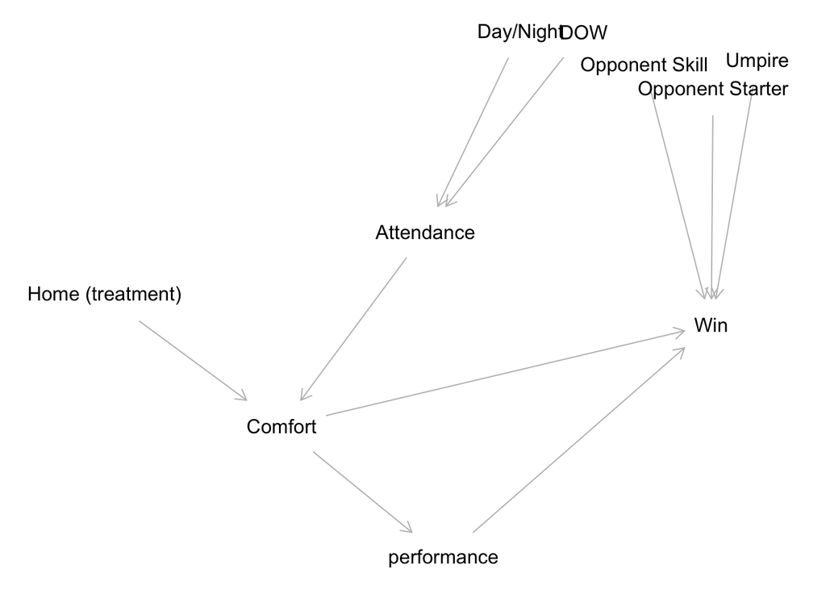

```r
library(dagitty)

# Define the DAG
dag <- dagitty('
dag {
  bb="-8,-6,10,0"
  "Day/Night" [pos="2.887,-4.914"]
  "Home (treatment)" [exposure,pos="-6.498,-4.544"]
  "Opponent Skill" [pos="5.682,-4.867"]
  "Opponent Starter" [pos="7.232,-4.833"]
  Attendance [pos="0.745,-4.633"]
  Comfort [pos="-2.499,-4.360"]
  DOW [pos="4.315,-4.915"]
  Umpire [pos="8.232,-4.873"]
  Win [outcome,pos="7.191,-4.503"]
  performance [pos="1.153,-4.174"]

  "Day/Night" -> Attendance
  "Home (treatment)" -> Comfort
  "Opponent Skill" -> Win
  "Opponent Starter" -> Win
  Attendance -> Comfort
  Comfort -> Win
  Comfort -> performance
  DOW -> Attendance
  Umpire -> Win
  performance -> Win
}
')

# Plot the DAG
plot(dag)
```

For our DAG plot, we chose to include the variables that we believed affected winning a game the most. While constructing the DAG plot, we observed that there are no true confounding variables, as being the home team is determined at the beginning of the season. We decided to use full matching as our method of analysis, matching on precision variables—those that can directly affect whether a team wins a game or not. Some variables are unmeasurable or would complicate the analysis significantly, such as the home plate umpire, since a team encounters a specific umpire behind home plate fewer than five times a year.

```r
library(dplyr)
library(tidyverse)
library(ggplot2)
library(tidyverse)
library(broom)
library(MatchIt)
library(marginaleffects)
library(dagitty)
library(scales)
library(cobalt)
```

```r
#Load the Data
ANA<-read_csv("Data/Team Datasets/ANA_games.csv")

ANA %>%
  dim()
## [1] 4356  124
ANA %>%
  names()
##   [1] "Date"                 "Year"                 "Month"
##   [4] "Day"                  "Game_Type"            "Dow"
##   [7] "Away_Team"            "Away_League"          "Away_Game_Number"
##  [10] "Home_Team"            "Home_League"          "Home_Game_Number"
##  [13] "Away_Score"           "Home_Score"           "Home_Away_Winner"
##  [16] "Team_Winner"          "Game_Outs"            "Day_Night"
##  [19] "Completion_Info"      "Forfeit_Info"         "Protest_Info"
##  [22] "ParkID"               "Attendance"           "Game_Length"
##  [25] "Away_Line"            "Home_Line"            "Away_AB"
##  [28] "Away_H"               "Away_2B"              "Away_3B"
##  [31] "Away_HR"              "Away_RBI"             "Away_SAC"
##  [34] "Away_SF"              "Away_HBP"             "Away_BB"
##  [37] "Away_IBB"             "Away_K"               "Away_SB"
##  [40] "Away_CS"              "Away_GIDP"            "Away_CI"
##  [43] "Away_LOB"             "Away_Pitchers"        "Away_ER"
##  [46] "Away_WP"              "Away_BLK"             "Away_PO"
##  [49] "Away_A"               "Away_E"               "Away_PB"
##  [52] "Away_DP"              "Away_TP"              "Home_AB"
##  [55] "Home_H"               "Home_2B"              "Home_3B"
##  [58] "Home_HR"              "Home_RBI"             "Home_SAC"
##  [61] "Home_SF"              "Home_HBP"             "Home_BB"
##  [64] "Home_IBB"             "Home_K"               "Home_SB"
##  [67] "Home_CS"              "Home_GIDP"            "Home_CI"
##  [70] "Home_LOB"             "Home_Pitchers"        "Home_ER"
##  [73] "Home_WP"              "Home_BLK"             "Home_PO"
##  [76] "Home_A"               "Home_E"               "Home_PB"
##  [79] "Home_DP"              "Home_TP"              "HP_Ump_ID"
##  [82] "HP_Ump_Name"          "X1B_Ump_ID"           "X1B_Ump_Name"
##  [85] "X2B_Ump_ID"           "X2B_Ump_Name"         "X3B_Ump_ID"
##  [88] "X3B_Ump_Name"         "LF_Ump_ID"            "LF_Ump_Name"
##  [91] "RF_Ump_ID"            "RF_Ump_Name"          "Away_Manage_ID"
##  [94] "Away_Manage_Name"     "Home_Manage_ID"       "Home_Manage_Name"
##  [97] "Winning_Pitcher_ID"   "Winning_Pitcher_Name" "Losing_Pitcher_ID"
## [100] "Losing_Pitcher_Name"  "Save"                 "Save_Pitcher_ID"
## [103] "Save_Pitcher_Name"    "GWRBI_ID"             "GWRBI_Name"
## [106] "Away_SP_ID"           "Away_SP_Name"         "Home_SP_ID"
## [109] "Home_SP_Name"         "Away_Win_Percentage"  "Away_Playoffs"
## [112] "Away_WS"              "Away_Win_P_Cat"       "Team"
## [115] "Home_Win_Percentage"  "Home_Playoffs"        "Home_WS"
## [118] "Home_Win_P_Cat"       "Home"                 "ANA_win"
## [121] "Opp_Win_Percentage"   "Opp_Playoffs"         "Opp_WS"
## [124] "Opp_Win_P_Cat"
```

## Estimating ATT Using Full Matching

```r
# Matching Method for ATT
match_out_full_ATT_ANA <- matchit(
    Home ~ Opp_Win_P_Cat + Opp_Playoffs + Opp_WS + Dow + Day_Night,
    data = ANA,
    method = "full",
    exact = ~ Opp_Win_P_Cat + Opp_Playoffs + Opp_WS + Dow + Day_Night,  # Example of exact matching variables
    distance = "glm",
    estimand = "ATT"
)
```

We used exact to full match with additional precision variables. While no variables in this dataset directly effect the causal path of interest there are variables that may significantly impact game outcome. These variables were determined as the categorical win pct variable, if the opp made playoffs, if the opp made WS, day of the week, and night/day games. Why do these improve the model / matching?

# Balance Statistics for ATT after Matching

```r
# For full matching
bal.tab(match_out_full_ATT_ANA)
## Balance Measures
##                            Type Diff.Adj
## distance               Distance        0
## Opp_Win_P_Cat_Bad        Binary        0
## Opp_Win_P_Cat_Good       Binary       -0
## Opp_Win_P_Cat_Great      Binary        0
## Opp_Win_P_Cat_Terrible   Binary        0
## Opp_Playoffs             Binary       -0
## Opp_WS                   Binary        0
## Dow_Fri                  Binary        0
## Dow_Mon                  Binary        0
## Dow_Sat                  Binary        0
## Dow_Sun                  Binary       -0
## Dow_Thu                  Binary        0
## Dow_Tue                  Binary        0
## Dow_Wed                  Binary        0
## Day_Night_N              Binary        0
##
## Sample sizes
##                      Control Treated
## All                  2176.      2180
## Matched (ESS)         585.34    2180
## Matched (Unweighted) 2153.      2180
## Unmatched              23.         0
```

[figure not shown]

```r
match_out_full_summ_ATT_ANA <- summary(match_out_full_ATT_ANA, interactions = TRUE)
plot(match_out_full_summ_ATT_ANA)
```

> Based on the balance summary plot provided above it appears that our matching method with precise variables is great. None of the variables, nor their interactions, are significantly different from one another when matched. This means that all matched cases are within a desirable range that is more accurate than when matching is not used. Considering that a wide range of data was used throughout the years this is great and shows that good matches were found.

# Common Support Plot

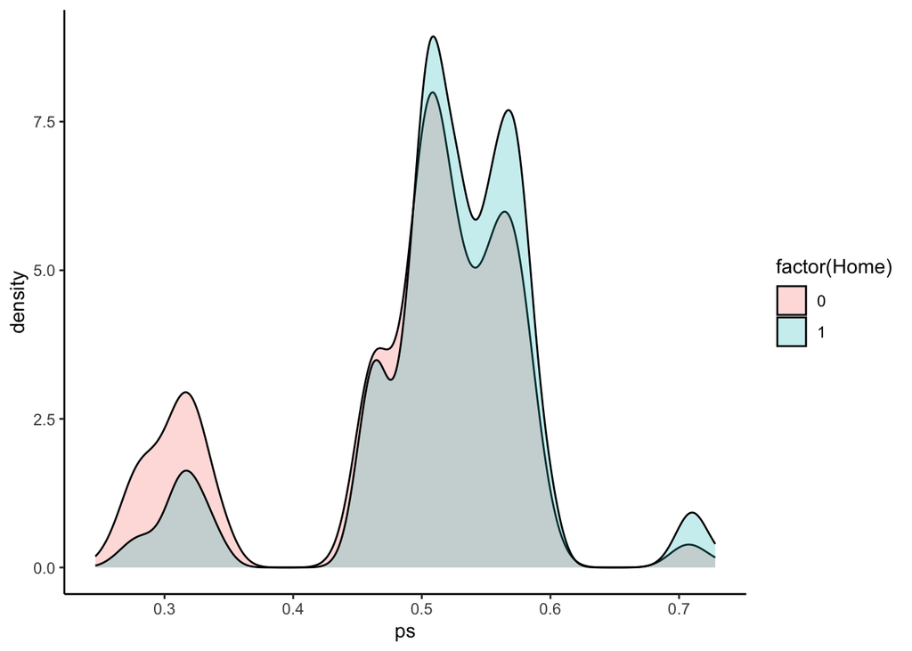

```r
# Getting ps scores from full
lalonde_with_ps_full_ATT_ANA <- ANA %>%
    mutate(ps = match_out_full_ATT_ANA$distance)

# Plot for full matching ANA ATT implementation
ggplot(lalonde_with_ps_full_ATT_ANA, aes(x = ps, fill = factor(Home))) +
  geom_density(alpha = 0.25) +
  theme_classic()
```

> The support plot is great and shows that the propensity score range is overlapped for both treatment and control groups. This essentially confirms that we are allowed to match based on this model and aren’t cutting out any significiant data. The supports our analysis.

# Extracting the matched data and estimating ATT

```r
# Extract Data
match_data_full_ATT_ANA <- match.data(match_out_full_ATT_ANA)

# Regression Model based on this matched data
mod2 <- lm(ANA_win ~ Home * (Opp_Win_P_Cat + Opp_Playoffs + Opp_WS + Attendance + Dow + Day_Night), data = match_data_full_ATT_ANA, weights = weights)

# Estimating ATT from model
avg_comparisons(
    mod2,
    variables = "Home",
    vcov = ~subclass,
    newdata = filter(match_data_full_ATT_ANA, Home == 1))
##
##  Estimate Std. Error    z Pr(>|z|)    S  2.5 % 97.5 %
##     0.094     0.0217 4.32   <0.001 16.0 0.0514  0.137
##
## Term: Home
## Type:  response
## Comparison: mean(1) - mean(0)
## Columns: term, contrast, estimate, std.error, statistic, p.value, s.value, conf.low, conf.high, predicted_lo, predicted_hi, predicted
```

> For all Angle’s home games, if they had been played away, we would expect their winning percentage to be 9.4% less. This equates to about 7.6 games, meaning the Angels would’ve lost about 8 games more if they had played every home game as an away game.

## Estimating ATC using full matching model

```r
# Matching method for ATC, using same precision variables
match_out_full_ATC_ANA <- matchit(
    Home ~ Opp_Win_P_Cat + Opp_Playoffs + Opp_WS + Dow + Day_Night,
    data = ANA,
    method = "full",
    exact = ~ Opp_Win_P_Cat + Opp_Playoffs + Opp_WS + Dow + Day_Night,
    distance = "glm",
    estimand = "ATC"
)
```

## Balance Statitics and Plot for ATC

```r
# Balance Table
bal.tab(match_out_full_ATC_ANA)
## Balance Measures
##                            Type Diff.Adj
## distance               Distance       -0
## Opp_Win_P_Cat_Bad        Binary        0
## Opp_Win_P_Cat_Good       Binary        0
## Opp_Win_P_Cat_Great      Binary        0
## Opp_Win_P_Cat_Terrible   Binary       -0
## Opp_Playoffs             Binary        0
## Opp_WS                   Binary       -0
## Dow_Fri                  Binary        0
## Dow_Mon                  Binary        0
## Dow_Sat                  Binary        0
## Dow_Sun                  Binary       -0
## Dow_Thu                  Binary        0
## Dow_Tue                  Binary        0
## Dow_Wed                  Binary       -0
## Day_Night_N              Binary       -0
##
## Sample sizes
##                      Control Treated
## All                     2176 2180.
## Matched (ESS)           2153  589.97
## Matched (Unweighted)    2153 2180.
## Unmatched                 23    0.
```

> Same as above for ATT, only 23 cases in the control category are without matches.

```r
# Matched Summary
match_out_full_summ_ATC_ANA <- summary(match_out_full_ATC_ANA, interactions = TRUE)
match_out_full_summ_ATC_ANA
##
## Call:
## matchit(formula = Home ~ Opp_Win_P_Cat + Opp_Playoffs + Opp_WS +
##     Dow + Day_Night, data = ANA, method = "full", distance = "glm",
##     estimand = "ATC", exact = ~Opp_Win_P_Cat + Opp_Playoffs +
##         Opp_WS + Dow + Day_Night)
##
## Summary of Balance for All Data:
##                                    Means Treated Means Control Std. Mean Diff.
## distance                                  0.5163        0.4846          0.3295
## Opp_Win_P_CatBad                          0.4440        0.4426          0.0030
## Opp_Win_P_CatGood                         0.4596        0.4628         -0.0063
## Opp_Win_P_CatGreat                        0.0592        0.0584          0.0035
## Opp_Win_P_CatTerrible                     0.0372        0.0363          0.0045
## Opp_Playoffs                              0.3041        0.3194         -0.0327
## Opp_WS                                    0.0381        0.0395         -0.0074
## DowFri                                    0.1596        0.1585          0.0030
## DowMon                                    0.1128        0.1002          0.0422
## DowSat                                    0.1615        0.1645         -0.0082
## DowSun                                    0.1601        0.1595          0.0017
## DowThu                                    0.0986        0.1163         -0.0550
## DowTue                                    0.1532        0.1526          0.0018
## DowWed                                    0.1541        0.1484          0.0160
## Day_NightD                                0.2119        0.3359         -0.2626
## Day_NightN                                0.7881        0.6641          0.2626
## Opp_Win_P_CatBad * DowFri                 0.0706        0.0666          0.0161
## Opp_Win_P_CatBad * DowMon                 0.0491        0.0455          0.0172
## Opp_Win_P_CatBad * DowSat                 0.0706        0.0699          0.0031
## Opp_Win_P_CatBad * DowSun                 0.0716        0.0680          0.0141
## Opp_Win_P_CatBad * DowThu                 0.0463        0.0524         -0.0272
## Opp_Win_P_CatBad * DowTue                 0.0674        0.0717         -0.0165
## Opp_Win_P_CatBad * DowWed                 0.0683        0.0685         -0.0005
## Opp_Win_P_CatBad * Day_NightD             0.0908        0.1438         -0.1511
## Opp_Win_P_CatBad * Day_NightN             0.3532        0.2987          0.1191
## Opp_Win_P_CatGood * Opp_Playoffs          0.2450        0.2610         -0.0366
## Opp_Win_P_CatGood * Opp_WS                0.0220        0.0239         -0.0123
## Opp_Win_P_CatGood * DowFri                0.0748        0.0763         -0.0057
## Opp_Win_P_CatGood * DowMon                0.0541        0.0464          0.0367
## Opp_Win_P_CatGood * DowSat                0.0761        0.0781         -0.0074
## Opp_Win_P_CatGood * DowSun                0.0743        0.0767         -0.0091
## Opp_Win_P_CatGood * DowThu                0.0399        0.0524         -0.0560
## Opp_Win_P_CatGood * DowTue                0.0697        0.0671          0.0105
## Opp_Win_P_CatGood * DowWed                0.0706        0.0657          0.0199
## Opp_Win_P_CatGood * Day_NightD            0.1037        0.1618         -0.1578
## Opp_Win_P_CatGood * Day_NightN            0.3560        0.3010          0.1198
## Opp_Win_P_CatGreat * Opp_WS               0.0161        0.0156          0.0035
## Opp_Win_P_CatGreat * DowFri               0.0078        0.0083         -0.0052
## Opp_Win_P_CatGreat * DowMon               0.0055        0.0055         -0.0001
## Opp_Win_P_CatGreat * DowSat               0.0083        0.0083         -0.0002
## Opp_Win_P_CatGreat * DowSun               0.0078        0.0074          0.0052
## Opp_Win_P_CatGreat * DowThu               0.0092        0.0083          0.0100
## Opp_Win_P_CatGreat * DowTue               0.0106        0.0101          0.0044
## Opp_Win_P_CatGreat * DowWed               0.0101        0.0106         -0.0047
## Opp_Win_P_CatGreat * Day_NightD           0.0106        0.0170         -0.0499
## Opp_Win_P_CatGreat * Day_NightN           0.0486        0.0414          0.0365
## Opp_Win_P_CatTerrible * DowFri            0.0064        0.0074         -0.0109
## Opp_Win_P_CatTerrible * DowMon            0.0041        0.0028          0.0261
## Opp_Win_P_CatTerrible * DowSat            0.0064        0.0083         -0.0204
## Opp_Win_P_CatTerrible * DowSun            0.0064        0.0074         -0.0109
## Opp_Win_P_CatTerrible * DowThu            0.0032        0.0032         -0.0001
## Opp_Win_P_CatTerrible * DowTue            0.0055        0.0037          0.0302
## Opp_Win_P_CatTerrible * DowWed            0.0050        0.0037          0.0226
## Opp_Win_P_CatTerrible * Day_NightD        0.0069        0.0133         -0.0562
## Opp_Win_P_CatTerrible * Day_NightN        0.0303        0.0230          0.0487
## Opp_Playoffs * Opp_WS                     0.0381        0.0395         -0.0074
## Opp_Playoffs * DowFri                     0.0491        0.0538         -0.0208
## Opp_Playoffs * DowMon                     0.0339        0.0294          0.0268
## Opp_Playoffs * DowSat                     0.0505        0.0551         -0.0205
## Opp_Playoffs * DowSun                     0.0486        0.0538         -0.0228
## Opp_Playoffs * DowThu                     0.0307        0.0358         -0.0275
## Opp_Playoffs * DowTue                     0.0454        0.0460         -0.0026
## Opp_Playoffs * DowWed                     0.0459        0.0455          0.0018
## Opp_Playoffs * Day_NightD                 0.0642        0.1117         -0.1507
## Opp_Playoffs * Day_NightN                 0.2399        0.2077          0.0793
## Opp_WS * DowFri                           0.0060        0.0069         -0.0112
## Opp_WS * DowMon                           0.0041        0.0037          0.0075
## Opp_WS * DowSat                           0.0060        0.0074         -0.0163
## Opp_WS * DowSun                           0.0055        0.0060         -0.0061
## Opp_WS * DowThu                           0.0046        0.0046         -0.0001
## Opp_WS * DowTue                           0.0060        0.0051          0.0128
## Opp_WS * DowWed                           0.0060        0.0060         -0.0001
## Opp_WS * Day_NightD                       0.0055        0.0124         -0.0624
## Opp_WS * Day_NightN                       0.0326        0.0271          0.0336
## DowFri * Day_NightD                       0.0005        0.0046         -0.0612
## DowFri * Day_NightN                       0.1592        0.1540          0.0145
## DowMon * Day_NightD                       0.0023        0.0170         -0.1138
## DowMon * Day_NightN                       0.1106        0.0832          0.0991
## DowSat * Day_NightD                       0.0289        0.0781         -0.1834
## DowSat * Day_NightN                       0.1326        0.0864          0.1643
## DowSun * Day_NightD                       0.1289        0.1448         -0.0451
## DowSun * Day_NightN                       0.0312        0.0147          0.1370
## DowThu * Day_NightD                       0.0142        0.0464         -0.1530
## DowThu * Day_NightN                       0.0844        0.0699          0.0571
## DowTue * Day_NightD                       0.0037        0.0101         -0.0644
## DowTue * Day_NightN                       0.1495        0.1425          0.0203
## DowWed * Day_NightD                       0.0335        0.0349         -0.0078
## DowWed * Day_NightN                       0.1206        0.1135          0.0225
##                                    Var. Ratio eCDF Mean eCDF Max
## distance                               0.6614    0.0709   0.1265
## Opp_Win_P_CatBad                            .    0.0015   0.0015
## Opp_Win_P_CatGood                           .    0.0031   0.0031
## Opp_Win_P_CatGreat                          .    0.0008   0.0008
## Opp_Win_P_CatTerrible                       .    0.0009   0.0009
## Opp_Playoffs                                .    0.0153   0.0153
## Opp_WS                                      .    0.0014   0.0014
## DowFri                                      .    0.0011   0.0011
## DowMon                                      .    0.0127   0.0127
## DowSat                                      .    0.0031   0.0031
## DowSun                                      .    0.0006   0.0006
## DowThu                                      .    0.0176   0.0176
## DowTue                                      .    0.0006   0.0006
## DowWed                                      .    0.0057   0.0057
## Day_NightD                                  .    0.1240   0.1240
## Day_NightN                                  .    0.1240   0.1240
## Opp_Win_P_CatBad * DowFri                   .    0.0040   0.0040
## Opp_Win_P_CatBad * DowMon                   .    0.0036   0.0036
## Opp_Win_P_CatBad * DowSat                   .    0.0008   0.0008
## Opp_Win_P_CatBad * DowSun                   .    0.0035   0.0035
## Opp_Win_P_CatBad * DowThu                   .    0.0061   0.0061
## Opp_Win_P_CatBad * DowTue                   .    0.0043   0.0043
## Opp_Win_P_CatBad * DowWed                   .    0.0001   0.0001
## Opp_Win_P_CatBad * Day_NightD               .    0.0530   0.0530
## Opp_Win_P_CatBad * Day_NightN               .    0.0545   0.0545
## Opp_Win_P_CatGood * Opp_Playoffs            .    0.0161   0.0161
## Opp_Win_P_CatGood * Opp_WS                  .    0.0019   0.0019
## Opp_Win_P_CatGood * DowFri                  .    0.0015   0.0015
## Opp_Win_P_CatGood * DowMon                  .    0.0077   0.0077
## Opp_Win_P_CatGood * DowSat                  .    0.0020   0.0020
## Opp_Win_P_CatGood * DowSun                  .    0.0024   0.0024
## Opp_Win_P_CatGood * DowThu                  .    0.0125   0.0125
## Opp_Win_P_CatGood * DowTue                  .    0.0026   0.0026
## Opp_Win_P_CatGood * DowWed                  .    0.0049   0.0049
## Opp_Win_P_CatGood * Day_NightD              .    0.0581   0.0581
## Opp_Win_P_CatGood * Day_NightN              .    0.0550   0.0550
## Opp_Win_P_CatGreat * Opp_WS                 .    0.0004   0.0004
## Opp_Win_P_CatGreat * DowFri                 .    0.0005   0.0005
## Opp_Win_P_CatGreat * DowMon                 .    0.0000   0.0000
## Opp_Win_P_CatGreat * DowSat                 .    0.0000   0.0000
## Opp_Win_P_CatGreat * DowSun                 .    0.0004   0.0004
## Opp_Win_P_CatGreat * DowThu                 .    0.0009   0.0009
## Opp_Win_P_CatGreat * DowTue                 .    0.0004   0.0004
## Opp_Win_P_CatGreat * DowWed                 .    0.0005   0.0005
## Opp_Win_P_CatGreat * Day_NightD             .    0.0065   0.0065
## Opp_Win_P_CatGreat * Day_NightN             .    0.0073   0.0073
## Opp_Win_P_CatTerrible * DowFri              .    0.0009   0.0009
## Opp_Win_P_CatTerrible * DowMon              .    0.0014   0.0014
## Opp_Win_P_CatTerrible * DowSat              .    0.0019   0.0019
## Opp_Win_P_CatTerrible * DowSun              .    0.0009   0.0009
## Opp_Win_P_CatTerrible * DowThu              .    0.0000   0.0000
## Opp_Win_P_CatTerrible * DowTue              .    0.0018   0.0018
## Opp_Win_P_CatTerrible * DowWed              .    0.0014   0.0014
## Opp_Win_P_CatTerrible * Day_NightD          .    0.0064   0.0064
## Opp_Win_P_CatTerrible * Day_NightN          .    0.0073   0.0073
## Opp_Playoffs * Opp_WS                       .    0.0014   0.0014
## Opp_Playoffs * DowFri                       .    0.0047   0.0047
## Opp_Playoffs * DowMon                       .    0.0045   0.0045
## Opp_Playoffs * DowSat                       .    0.0047   0.0047
## Opp_Playoffs * DowSun                       .    0.0051   0.0051
## Opp_Playoffs * DowThu                       .    0.0051   0.0051
## Opp_Playoffs * DowTue                       .    0.0005   0.0005
```

```r
## Opp_Playoffs * DowWed                       .    0.0004   0.0004
## Opp_Playoffs * Day_NightD                   .    0.0475   0.0475
## Opp_Playoffs * Day_NightN                   .    0.0322   0.0322
## Opp_WS * DowFri                             .    0.0009   0.0009
## Opp_WS * DowMon                             .    0.0005   0.0005
## Opp_WS * DowSat                             .    0.0014   0.0014
## Opp_WS * DowSun                             .    0.0005   0.0005
## Opp_WS * DowThu                             .    0.0000   0.0000
## Opp_WS * DowTue                             .    0.0009   0.0009
## Opp_WS * DowWed                             .    0.0000   0.0000
## Opp_WS * Day_NightD                         .    0.0069   0.0069
## Opp_WS * Day_NightN                         .    0.0055   0.0055
## DowFri * Day_NightD                         .    0.0041   0.0041
## DowFri * Day_NightN                         .    0.0052   0.0052
## DowMon * Day_NightD                         .    0.0147   0.0147
## DowMon * Day_NightN                         .    0.0274   0.0274
## DowSat * Day_NightD                         .    0.0492   0.0492
## DowSat * Day_NightN                         .    0.0462   0.0462
## DowSun * Day_NightD                         .    0.0159   0.0159
## DowSun * Day_NightN                         .    0.0165   0.0165
## DowThu * Day_NightD                         .    0.0322   0.0322
## DowThu * Day_NightN                         .    0.0146   0.0146
## DowTue * Day_NightD                         .    0.0064   0.0064
## DowTue * Day_NightN                         .    0.0071   0.0071
## DowWed * Day_NightD                         .    0.0014   0.0014
## DowWed * Day_NightN                         .    0.0071   0.0071
##
## Summary of Balance for Matched Data:
##                                    Means Treated Means Control Std. Mean Diff.
## distance                                  0.4864        0.4864              -0
## Opp_Win_P_CatBad                          0.4473        0.4473               0
## Opp_Win_P_CatGood                         0.4631        0.4631               0
## Opp_Win_P_CatGreat                        0.0581        0.0581               0
## Opp_Win_P_CatTerrible                     0.0316        0.0316              -0
## Opp_Playoffs                              0.3186        0.3186               0
## Opp_WS                                    0.0372        0.0372              -0
## DowFri                                    0.1570        0.1570               0
## DowMon                                    0.0999        0.0999               0
## DowSat                                    0.1616        0.1616               0
## DowSun                                    0.1607        0.1607              -0
## DowThu                                    0.1170        0.1170               0
## DowTue                                    0.1542        0.1542               0
## DowWed                                    0.1496        0.1496              -0
## Day_NightD                                0.3293        0.3293               0
## Day_NightN                                0.6707        0.6707              -0
## Opp_Win_P_CatBad * DowFri                 0.0673        0.0673               0
## Opp_Win_P_CatBad * DowMon                 0.0460        0.0460              -0
## Opp_Win_P_CatBad * DowSat                 0.0706        0.0706               0
## Opp_Win_P_CatBad * DowSun                 0.0687        0.0687              -0
## Opp_Win_P_CatBad * DowThu                 0.0529        0.0529               0
## Opp_Win_P_CatBad * DowTue                 0.0725        0.0725               0
## Opp_Win_P_CatBad * DowWed                 0.0692        0.0692              -0
## Opp_Win_P_CatBad * Day_NightD             0.1454        0.1454               0
## Opp_Win_P_CatBad * Day_NightN             0.3019        0.3019              -0
## Opp_Win_P_CatGood * Opp_Playoffs          0.2606        0.2606               0
## Opp_Win_P_CatGood * Opp_WS                0.0223        0.0223               0
## Opp_Win_P_CatGood * DowFri                0.0739        0.0739               0
## Opp_Win_P_CatGood * DowMon                0.0460        0.0460               0
## Opp_Win_P_CatGood * DowSat                0.0790        0.0790               0
## Opp_Win_P_CatGood * DowSun                0.0776        0.0776               0
## Opp_Win_P_CatGood * DowThu                0.0529        0.0529               0
## Opp_Win_P_CatGood * DowTue                0.0678        0.0678               0
## Opp_Win_P_CatGood * DowWed                0.0660        0.0660               0
## Opp_Win_P_CatGood * Day_NightD            0.1588        0.1588               0
## Opp_Win_P_CatGood * Day_NightN            0.3042        0.3042              -0
## Opp_Win_P_CatGreat * Opp_WS               0.0149        0.0149              -0
## Opp_Win_P_CatGreat * DowFri               0.0084        0.0084               0
## Opp_Win_P_CatGreat * DowMon               0.0056        0.0056               0
## Opp_Win_P_CatGreat * DowSat               0.0084        0.0084               0
## Opp_Win_P_CatGreat * DowSun               0.0070        0.0070               0
## Opp_Win_P_CatGreat * DowThu               0.0079        0.0079              -0
## Opp_Win_P_CatGreat * DowTue               0.0102        0.0102               0
## Opp_Win_P_CatGreat * DowWed               0.0107        0.0107               0
## Opp_Win_P_CatGreat * Day_NightD           0.0167        0.0167               0
## Opp_Win_P_CatGreat * Day_NightN           0.0413        0.0413               0
## Opp_Win_P_CatTerrible * DowFri            0.0074        0.0074              -0
## Opp_Win_P_CatTerrible * DowMon            0.0023        0.0023              -0
## Opp_Win_P_CatTerrible * DowSat            0.0037        0.0037              -0
## Opp_Win_P_CatTerrible * DowSun            0.0074        0.0074              -0
## Opp_Win_P_CatTerrible * DowThu            0.0033        0.0033              -0
## Opp_Win_P_CatTerrible * DowTue            0.0037        0.0037              -0
## Opp_Win_P_CatTerrible * DowWed            0.0037        0.0037              -0
## Opp_Win_P_CatTerrible * Day_NightD        0.0084        0.0084               0
## Opp_Win_P_CatTerrible * Day_NightN        0.0232        0.0232              -0
## Opp_Playoffs * Opp_WS                     0.0372        0.0372              -0
## Opp_Playoffs * DowFri                     0.0525        0.0525              -0
## Opp_Playoffs * DowMon                     0.0288        0.0288              -0
## Opp_Playoffs * DowSat                     0.0557        0.0557               0
## Opp_Playoffs * DowSun                     0.0539        0.0539              -0
## Opp_Playoffs * DowThu                     0.0358        0.0358               0
## Opp_Playoffs * DowTue                     0.0464        0.0464              -0
## Opp_Playoffs * DowWed                     0.0455        0.0455               0
## Opp_Playoffs * Day_NightD                 0.1092        0.1092               0
## Opp_Playoffs * Day_NightN                 0.2095        0.2095              -0
## Opp_WS * DowFri                           0.0065        0.0065              -0
## Opp_WS * DowMon                           0.0028        0.0028               0
## Opp_WS * DowSat                           0.0074        0.0074              -0
## Opp_WS * DowSun                           0.0056        0.0056               0
## Opp_WS * DowThu                           0.0042        0.0042               0
## Opp_WS * DowTue                           0.0051        0.0051               0
## Opp_WS * DowWed                           0.0056        0.0056              -0
## Opp_WS * Day_NightD                       0.0102        0.0102               0
## Opp_WS * Day_NightN                       0.0269        0.0269              -0
## DowFri * Day_NightD                       0.0014        0.0014               0
## DowFri * Day_NightN                       0.1556        0.1556              -0
## DowMon * Day_NightD                       0.0158        0.0158              -0
## DowMon * Day_NightN                       0.0841        0.0841               0
## DowSat * Day_NightD                       0.0743        0.0743              -0
## DowSat * Day_NightN                       0.0873        0.0873               0
## DowSun * Day_NightD                       0.1463        0.1463              -0
## DowSun * Day_NightN                       0.0144        0.0144              -0
## DowThu * Day_NightD                       0.0464        0.0464               0
## DowThu * Day_NightN                       0.0706        0.0706               0
## DowTue * Day_NightD                       0.0102        0.0102               0
## DowTue * Day_NightN                       0.1440        0.1440               0
## DowWed * Day_NightD                       0.0348        0.0348               0
## DowWed * Day_NightN                       0.1147        0.1147               0
##                                    Var. Ratio eCDF Mean eCDF Max
## distance                               1.0012         0        0
## Opp_Win_P_CatBad                            .         0        0
## Opp_Win_P_CatGood                           .         0        0
## Opp_Win_P_CatGreat                          .         0        0
## Opp_Win_P_CatTerrible                       .         0        0
## Opp_Playoffs                                .         0        0
## Opp_WS                                      .         0        0
## DowFri                                      .         0        0
## DowMon                                      .         0        0
## DowSat                                      .         0        0
## DowSun                                      .         0        0
## DowThu                                      .         0        0
## DowTue                                      .         0        0
## DowWed                                      .         0        0
## Day_NightD                                  .         0        0
## Day_NightN                                  .         0        0
## Opp_Win_P_CatBad * DowFri                   .         0        0
## Opp_Win_P_CatBad * DowMon                   .         0        0
## Opp_Win_P_CatBad * DowSat                   .         0        0
## Opp_Win_P_CatBad * DowSun                   .         0        0
## Opp_Win_P_CatBad * DowThu                   .         0        0
## Opp_Win_P_CatBad * DowTue                   .         0        0
## Opp_Win_P_CatBad * DowWed                   .         0        0
## Opp_Win_P_CatBad * Day_NightD               .         0        0
## Opp_Win_P_CatBad * Day_NightN               .         0        0
## Opp_Win_P_CatGood * Opp_Playoffs            .         0        0
## Opp_Win_P_CatGood * Opp_WS                  .         0        0
## Opp_Win_P_CatGood * DowFri                  .         0        0
## Opp_Win_P_CatGood * DowMon                  .         0        0
## Opp_Win_P_CatGood * DowSat                  .         0        0
## Opp_Win_P_CatGood * DowSun                  .         0        0
## Opp_Win_P_CatGood * DowThu                  .         0        0
## Opp_Win_P_CatGood * DowTue                  .         0        0
## Opp_Win_P_CatGood * DowWed                  .         0        0
## Opp_Win_P_CatGood * Day_NightD              .         0        0
## Opp_Win_P_CatGood * Day_NightN              .         0        0
## Opp_Win_P_CatGreat * Opp_WS                 .         0        0
## Opp_Win_P_CatGreat * DowFri                 .         0        0
## Opp_Win_P_CatGreat * DowMon                 .         0        0
## Opp_Win_P_CatGreat * DowSat                 .         0        0
## Opp_Win_P_CatGreat * DowSun                 .         0        0
## Opp_Win_P_CatGreat * DowThu                 .         0        0
```

```r
## Opp_Win_P_CatGreat * DowTue                 .         0        0
## Opp_Win_P_CatGreat * DowWed                 .         0        0
## Opp_Win_P_CatGreat * Day_NightD             .         0        0
## Opp_Win_P_CatGreat * Day_NightN             .         0        0
## Opp_Win_P_CatTerrible * DowFri              .         0        0
## Opp_Win_P_CatTerrible * DowMon              .         0        0
## Opp_Win_P_CatTerrible * DowSat              .         0        0
## Opp_Win_P_CatTerrible * DowSun              .         0        0
## Opp_Win_P_CatTerrible * DowThu              .         0        0
## Opp_Win_P_CatTerrible * DowTue              .         0        0
## Opp_Win_P_CatTerrible * DowWed              .         0        0
## Opp_Win_P_CatTerrible * Day_NightD          .         0        0
## Opp_Win_P_CatTerrible * Day_NightN          .         0        0
## Opp_Playoffs * Opp_WS                       .         0        0
## Opp_Playoffs * DowFri                       .         0        0
## Opp_Playoffs * DowMon                       .         0        0
## Opp_Playoffs * DowSat                       .         0        0
## Opp_Playoffs * DowSun                       .         0        0
## Opp_Playoffs * DowThu                       .         0        0
## Opp_Playoffs * DowTue                       .         0        0
## Opp_Playoffs * DowWed                       .         0        0
## Opp_Playoffs * Day_NightD                   .         0        0
## Opp_Playoffs * Day_NightN                   .         0        0
## Opp_WS * DowFri                             .         0        0
## Opp_WS * DowMon                             .         0        0
## Opp_WS * DowSat                             .         0        0
## Opp_WS * DowSun                             .         0        0
## Opp_WS * DowThu                             .         0        0
## Opp_WS * DowTue                             .         0        0
## Opp_WS * DowWed                             .         0        0
## Opp_WS * Day_NightD                         .         0        0
## Opp_WS * Day_NightN                         .         0        0
## DowFri * Day_NightD                         .         0        0
## DowFri * Day_NightN                         .         0        0
## DowMon * Day_NightD                         .         0        0
## DowMon * Day_NightN                         .         0        0
## DowSat * Day_NightD                         .         0        0
## DowSat * Day_NightN                         .         0        0
## DowSun * Day_NightD                         .         0        0
## DowSun * Day_NightN                         .         0        0
## DowThu * Day_NightD                         .         0        0
## DowThu * Day_NightN                         .         0        0
## DowTue * Day_NightD                         .         0        0
## DowTue * Day_NightN                         .         0        0
## DowWed * Day_NightD                         .         0        0
## DowWed * Day_NightN                         .         0        0
##                                    Std. Pair Dist.
## distance                                         0
## Opp_Win_P_CatBad                                 0
## Opp_Win_P_CatGood                                0
## Opp_Win_P_CatGreat                               0
## Opp_Win_P_CatTerrible                            0
## Opp_Playoffs                                     0
## Opp_WS                                           0
## DowFri                                           0
## DowMon                                           0
## DowSat                                           0
## DowSun                                           0
## DowThu                                           0
## DowTue                                           0
## DowWed                                           0
## Day_NightD                                       0
## Day_NightN                                       0
## Opp_Win_P_CatBad * DowFri                        0
## Opp_Win_P_CatBad * DowMon                        0
## Opp_Win_P_CatBad * DowSat                        0
## Opp_Win_P_CatBad * DowSun                        0
## Opp_Win_P_CatBad * DowThu                        0
## Opp_Win_P_CatBad * DowTue                        0
## Opp_Win_P_CatBad * DowWed                        0
## Opp_Win_P_CatBad * Day_NightD                    0
## Opp_Win_P_CatBad * Day_NightN                    0
## Opp_Win_P_CatGood * Opp_Playoffs                 0
## Opp_Win_P_CatGood * Opp_WS                       0
## Opp_Win_P_CatGood * DowFri                       0
## Opp_Win_P_CatGood * DowMon                       0
## Opp_Win_P_CatGood * DowSat                       0
## Opp_Win_P_CatGood * DowSun                       0
## Opp_Win_P_CatGood * DowThu                       0
## Opp_Win_P_CatGood * DowTue                       0
## Opp_Win_P_CatGood * DowWed                       0
## Opp_Win_P_CatGood * Day_NightD                   0
## Opp_Win_P_CatGood * Day_NightN                   0
## Opp_Win_P_CatGreat * Opp_WS                      0
## Opp_Win_P_CatGreat * DowFri                      0
## Opp_Win_P_CatGreat * DowMon                      0
## Opp_Win_P_CatGreat * DowSat                      0
## Opp_Win_P_CatGreat * DowSun                      0
## Opp_Win_P_CatGreat * DowThu                      0
## Opp_Win_P_CatGreat * DowTue                      0
## Opp_Win_P_CatGreat * DowWed                      0
## Opp_Win_P_CatGreat * Day_NightD                  0
## Opp_Win_P_CatGreat * Day_NightN                  0
## Opp_Win_P_CatTerrible * DowFri                   0
## Opp_Win_P_CatTerrible * DowMon                   0
## Opp_Win_P_CatTerrible * DowSat                   0
## Opp_Win_P_CatTerrible * DowSun                   0
## Opp_Win_P_CatTerrible * DowThu                   0
## Opp_Win_P_CatTerrible * DowTue                   0
## Opp_Win_P_CatTerrible * DowWed                   0
## Opp_Win_P_CatTerrible * Day_NightD               0
## Opp_Win_P_CatTerrible * Day_NightN               0
## Opp_Playoffs * Opp_WS                            0
## Opp_Playoffs * DowFri                            0
## Opp_Playoffs * DowMon                            0
## Opp_Playoffs * DowSat                            0
## Opp_Playoffs * DowSun                            0
## Opp_Playoffs * DowThu                            0
## Opp_Playoffs * DowTue                            0
## Opp_Playoffs * DowWed                            0
## Opp_Playoffs * Day_NightD                        0
## Opp_Playoffs * Day_NightN                        0
## Opp_WS * DowFri                                  0
## Opp_WS * DowMon                                  0
## Opp_WS * DowSat                                  0
## Opp_WS * DowSun                                  0
## Opp_WS * DowThu                                  0
## Opp_WS * DowTue                                  0
## Opp_WS * DowWed                                  0
## Opp_WS * Day_NightD                              0
## Opp_WS * Day_NightN                              0
## DowFri * Day_NightD                              0
## DowFri * Day_NightN                              0
## DowMon * Day_NightD                              0
## DowMon * Day_NightN                              0
## DowSat * Day_NightD                              0
## DowSat * Day_NightN                              0
## DowSun * Day_NightD                              0
## DowSun * Day_NightN                              0
## DowThu * Day_NightD                              0
## DowThu * Day_NightN                              0
## DowTue * Day_NightD                              0
## DowTue * Day_NightN                              0
## DowWed * Day_NightD                              0
## DowWed * Day_NightN                              0
##
## Sample Sizes:
##               Control Treated
## All              2176 2180.
## Matched (ESS)    2153  589.97
## Matched          2153 2180.
## Unmatched          23    0.
## Discarded           0    0.
```

> Mean difference is zero for all variables and their interaction terms, which is much better than the summary of balance for all data.

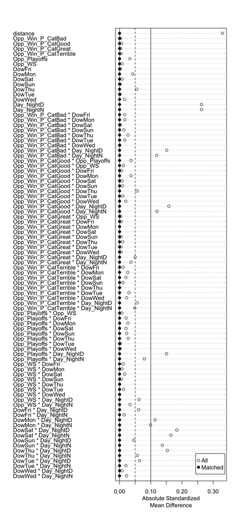

```r
# Plot visualizing what is described above
plot(match_out_full_summ_ATC_ANA)
```

# Common Support Plot

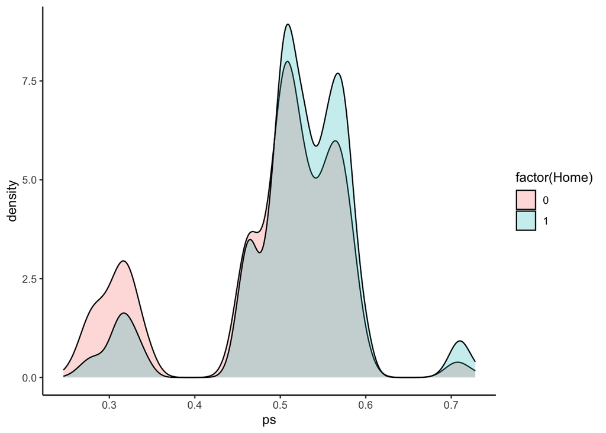

```r
# Getting ps scores from full
lalonde_with_ps_full_ATC_ANA <- ANA %>%
    mutate(ps = match_out_full_ATC_ANA$distance)

# Plot for full matching ANA ATT implementation
ggplot(lalonde_with_ps_full_ATC_ANA, aes(x = ps, fill = factor(Home))) +
  geom_density(alpha = 0.25) +
  theme_classic()
```

> Common support plot is the same, whihc was to be expected and makes sense. Again, this is a good sign for our analysis.

# Extracting Matched Data and Estimating ATC

```r
# Extract
match_data_full_ATC_ANA <- match.data(match_out_full_ATC_ANA)

# Model Creation
mod3 <- lm(ANA_win ~ Home * (Opp_Win_P_Cat + Opp_Playoffs + Opp_WS + Dow + Day_Night), data = match_data_full_ATC_ANA, weights = weights)

# Estimate
avg_comparisons(
    mod3,
    variables = "Home",
    vcov = ~subclass,
    newdata = filter(match_data_full_ATC_ANA, Home == 0))
##
##  Estimate Std. Error    z Pr(>|z|)   S  2.5 % 97.5 %
##    0.0664     0.0228 2.91  0.00363 8.1 0.0217  0.111
##
## Term: Home
## Type:  response
## Comparison: mean(1) - mean(0)
## Columns: term, contrast, estimate, std.error, statistic, p.value, s.value, conf.low, conf.high, predicted_lo, predicted_hi, predicted
```

> For all Angel’s away games, if they had been played at home, we would expect their winning percentage to be 6.6% greater. This equates to about 5.3 games, meaning the Angels would’ve won about 5 games more if they had played every away game as a home game.

# Estimating ATE using Matching

```r
# Matching method for ATE, using same precision variables
match_out_full_ATE_ANA <- matchit(
    Home ~ Opp_Win_P_Cat + Opp_Playoffs + Opp_WS + Dow + Day_Night,
    data = ANA,
    method = "full",
    exact = ~ Opp_Win_P_Cat + Opp_Playoffs + Opp_WS + Dow + Day_Night,
    distance = "glm",
    estimand = "ATE"
)
```

# Extracting and Estimating

```r
# Extracting
match_data_full_ATE_ANA <- match.data(match_out_full_ATE_ANA)

# Model for ATE
mod4 <- lm(ANA_win ~ Home * (Opp_Win_P_Cat + Opp_Playoffs + Opp_WS + Dow + Day_Night), data = match_data_full_ATE_ANA, weights = weights)

# Estimation
avg_comparisons(
    mod4,
    variables = "Home",
    vcov = ~subclass)
##
##  Estimate Std. Error    z Pr(>|z|)    S  2.5 % 97.5 %
##    0.0803     0.0188 4.26   <0.001 15.6 0.0433  0.117
##
## Term: Home
## Type:  response
## Comparison: mean(1) - mean(0)
## Columns: term, contrast, estimate, std.error, statistic, p.value, s.value, conf.low, conf.high, predicted_lo, predicted_hi, predicted
```

> If the Angels played every game away, we would expect the Angels win percentage to be 8% lower than if they played every game at home. This equates to about 12.93 games which means the Angels would win 13 games more if they played every game at home versus every game away. This is very interesting considering this could be the difference between winning your division and not making the playoffs.

# Conclusion

For the Angels specifically, there is a relevant causal effect for playing at home on winning a specific game. We will analyze the other 29 teams and rank them for each category to further analyze the effect of being the home team on winning games.